# Census Income project

# b)Build a multiple logistic regression model as follows:

● Divide the dataset into training and test sets in 80:20 ratio. ● Build a logistic regression model where the dependent variable is “X”(yearly income) and independent variables are “age”, “workclass”, and “education”. ● Predict the values on the test set. ● Build a confusion matrix and find the accuracy.

```python
#LOgistic Regressionfrom
from sklearn.linear_model import LogisticRegression
from sklearn.preprocessing import StandardScaler, LabelEncoder
from sklearn.metrics import accuracy_score,confusion_matrix,classification_report
```

```python
lo=LogisticRegression()
```

```python
# giving particular labels to the elements in my columns

le=LabelEncoder()
```

```python
df.education = df.education.replace(['Preschool','1st-4th','5th-6th','7th-8th','9th','10th','11th','12th'],'School')
df['workclass']=le.fit_transform(df['workclass'])
df['education']=le.fit_transform(df['education'])
```

```python
x=df.loc[:,('age','workclass','education')]
x = pd.DataFrame(x)
x
```

|  | age | workclass | education |
| --- | --- | --- | --- |
| 0 | 39 | 7 | 9 |
| 1 | 50 | 6 | 9 |
| 2 | 38 | 4 | 11 |
| 3 | 53 | 4 | 1 |
| 4 | 28 | 4 | 9 |
| ... | ... | ... | ... |
| 32556 | 27 | 4 | 7 |
| 32557 | 40 | 4 | 11 |
| 32558 | 58 | 4 | 11 |
| 32559 | 22 | 4 | 11 |
| 32560 | 52 | 5 | 11 |

32561 rows × 3 columns

```python
y=df['income'].replace(' <=50K',0).replace(' >50K',1)
```

```python
y
```

```
0        0
1        0
2        0
3        0
4        0
        ..
32556    0
32557    1
32558    0
32559    0
32560    1
Name: income, Length: 32561, dtype: int64
```

```python
from sklearn.model_selection import train_test_split
```

```python
x_train,x_test,y_train,y_test=train_test_split(x,y,test_size=.20,random_state=42)
```

```python
lo.fit(x_train,y_train)
```

```
LogisticRegression()
```

```python
y_pred=lo.predict(x_test)
```

```python
accuracy_score(y_test,y_pred)
```

```
0.7454322124980808
```

```python
cm=confusion_matrix(y_pred,y_test)
cm
```

```
array([[4824, 1540],
       [ 118,   31]], dtype=int64)
```

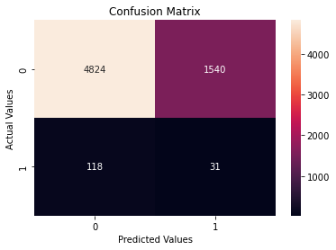

```python
plt.title('Confusion Matrix')
sns.heatmap(cm,annot = True, fmt= 'd')
plt.xlabel('Predicted Values')
plt.ylabel('Actual Values')
```

# 5. Decision Tree:

a) Build a decision tree model as follows: ● Divide the dataset into training and test sets in 70:30 ratio. ● Build a decision tree model where the dependent variable is “X”(Yearly Income) and the rest of the variables as independent variables. ● Predict the values on the test set. ● Build a confusion matrix and calculate the accuracy.

```python
#Decision Tree

from sklearn.tree import DecisionTreeClassifier
```

```python
df['education'].value_counts()
```

[output not shown]

```python
df.education = df.education.replace(['Preschool','1st-4th','5th-6th','7th-8th','9th','10th','11th','12th'],'School')
```

```python
df = df.apply(L.fit_transform)
```

```python
df.head()
```

|  | age | workclass | fnlwgt | education | education.num | marital.status | occupation | relationship | race | sex | capital.gain | capital.loss | hours.per.week | native.country | income |
| --- | --- | --- | --- | --- | --- | --- | --- | --- | --- | --- | --- | --- | --- | --- | --- |
| 0 | 22 | 7 | 2671 | 9 | 12 | 4 | 1 | 1 | 4 | 1 | 25 | 0 | 39 | 39 | 0 |
| 1 | 33 | 6 | 2926 | 9 | 12 | 2 | 4 | 0 | 4 | 1 | 0 | 0 | 12 | 39 | 0 |
| 2 | 21 | 4 | 14086 | 11 | 8 | 0 | 6 | 1 | 4 | 1 | 0 | 0 | 39 | 39 | 0 |
| 3 | 36 | 4 | 15336 | 1 | 6 | 2 | 6 | 0 | 2 | 1 | 0 | 0 | 39 | 39 | 0 |
| 4 | 11 | 4 | 19355 | 9 | 12 | 2 | 10 | 5 | 2 | 0 | 0 | 0 | 39 | 5 | 0 |

```python
x=df.iloc[:,:-1]
y=df.iloc[:,-1]
```

```python
x_train,x_test,y_train,y_test=train_test_split(x,y,test_size=.30,random_state=42)
```

```python
dt=DecisionTreeClassifier()
```

```python
dt.fit(x_train,y_train)
```

```
DecisionTreeClassifier()
```

```python
y_pred=dt.predict(x_test)
```

```python
accuracy_score(y_test,y_pred)
```

```
0.8088852492578564
```

```python
cm=confusion_matrix(y_pred,y_test)
cm
```

[output not shown]

```python
plt.title('Confusion Matrix')
sns.heatmap(cm,annot = True, fmt= 'd')
plt.xlabel('Predicted Values')
plt.ylabel('Actual Values')
```

# 6. Random Forest:

```python
#Random Forest
from sklearn.ensemble import RandomForestClassifier
```

```python
x_train,x_test,y_train,y_test=train_test_split(x,y,test_size=.20,random_state=42)
```

```python
rf=RandomForestClassifier()
```

```python
rf.fit(x_train,y_train)
```

```
RandomForestClassifier()
```

```python
y_pred=rf.predict(x_test)
```

```python
accuracy_score(y_test,y_pred)
```

```
0.8598188238906802
```

```python
cm=confusion_matrix(y_pred,y_test)
cm
```

[output not shown]

```python
plt.title('Confusion Matrix')
sns.heatmap(cm,annot = True, fmt= 'd')
plt.xlabel('Predicted Values')
plt.ylabel('Actual Values')
```

# 7. For this problem, use the population dataset, and perform the following:

```python
#import libraries
import pandas as pd
import matplotlib.pyplot as plt
import numpy as np
import seaborn as sns
```

```python
pop=pd.read_csv('popdata (3).csv')
```

```python
pop.head()
```

|  | value | date |
| --- | --- | --- |
| 0 | 127299.0 | 1952-01-01 |
| 1 | 127517.0 | 1952-02-01 |
| 2 | 127721.0 | 1952-03-01 |
| 3 | 127933.0 | 1952-04-01 |
| 4 | 128130.0 | 1952-05-01 |

```python
pop.info()
```

```
<class 'pandas.core.frame.DataFrame'>
RangeIndex: 816 entries, 0 to 815
Data columns (total 2 columns):
 #   Column  Non-Null Count  Dtype
---  ------  --------------  -----
 0   value   816 non-null    float64
 1   date    816 non-null    object
dtypes: float64(1), object(1)
memory usage: 12.9+ KB
```

```python
pop["date"]
```

```
0      1952-01-01
1      1952-02-01
2      1952-03-01
3      1952-04-01
4      1952-05-01
          ...
811    2019-08-01
812    2019-09-01
813    2019-10-01
814    2019-11-01
815    2019-12-01
Name: date, Length: 816, dtype: object
```

```python
pop['date'] = pd.to_datetime(pop['date'])
```

```python
pop['date']
```

```
0     1952-01-01
1     1952-02-01
2     1952-03-01
3     1952-04-01
4     1952-05-01
         ...
811   2019-08-01
812   2019-09-01
813   2019-10-01
814   2019-11-01
815   2019-12-01
Name: date, Length: 816, dtype: datetime64[ns]
```

```python
pop.date.info()
```

```
<class 'pandas.core.series.Series'>
RangeIndex: 816 entries, 0 to 815
Series name: date
Non-Null Count  Dtype
--------------  -----
816 non-null    datetime64[ns]
dtypes: datetime64[ns](1)
memory usage: 6.5 KB
```

```python
pop.index
```

```
RangeIndex(start=0, stop=816, step=1)
```

```python
pop.index=pop['date']
```

```python
del pop['date']
```

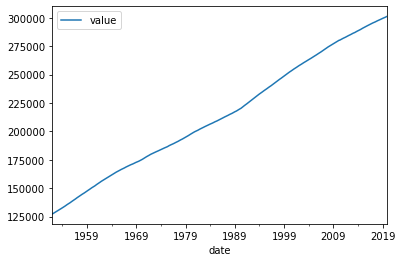

```python
pop.plot()
```

```python
from statsmodels.tsa.stattools import adfuller
#p-value > 0.05: ---> not stationary
#p-value <= 0.05: --> stationary
result = adfuller(pop['value'])
#print(result)
#print('ADF Statistic: %f' % result[0])
print('p-value: %f' % result[1])
#print('Critical Values:')
#for key, value in result[4].items():
	#print('\t%s: %.3f' % (key, value))
if result[1]>0.05:
	print('not stationary')
else:
	print("stationary")
```

```
p-value: 0.855530
not stationary
```

```python
from statsmodels.tsa.stattools import kpss
stats,p,lags,critical_values=kpss(pop['value'])
if p>0.05:
  print('stationary')
else:
  print("not stationary")
print(p)
```

```
not stationary
0.01
```

```python
rolling_mean = pop.rolling(window=12).mean()
```

```python
rolling_mean_detrended = pop - rolling_mean
```

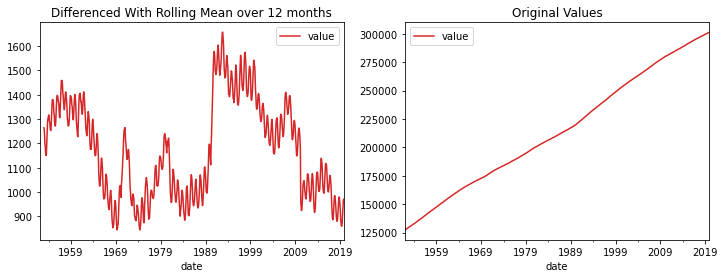

```python
ax1 = plt.subplot(121)
rolling_mean_detrended.plot(figsize=(12,4),color="tab:red",
                            title="Differenced With Rolling Mean over 12 months",
                            ax=ax1)
ax2 = plt.subplot(122)
pop.plot(figsize=(12,4),
          color="tab:red",
          title="Original Values",
          ax=ax2)
```

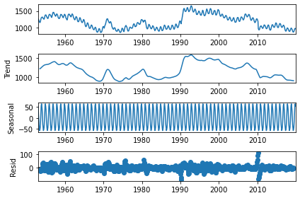

```python
from statsmodels.tsa.seasonal import seasonal_decompose
decompose_result = seasonal_decompose(rolling_mean_detrended.dropna())
#We can check the trend and seasonality using the
# seasonal_decompose() method.
decompose_result.plot();
```

```python
rolling_mean_detrended.head(12)
```

| date | value |
| --- | --- |
| 1952-01-01 | NaN |
| 1952-02-01 | NaN |
| 1952-03-01 | NaN |
| 1952-04-01 | NaN |
| 1952-05-01 | NaN |
| 1952-06-01 | NaN |
| 1952-07-01 | NaN |
| 1952-08-01 | NaN |
| 1952-09-01 | NaN |
| 1952-10-01 | NaN |
| 1952-11-01 | NaN |
| 1952-12-01 | 1264.416667 |

```python
rolling_mean_detrended.shift(2).head(24)
```

| date | value |
| --- | --- |
| 1952-01-01 | NaN |
| 1952-02-01 | NaN |
| 1952-03-01 | NaN |
| 1952-04-01 | NaN |
| 1952-05-01 | NaN |
| 1952-06-01 | NaN |
| 1952-07-01 | NaN |
| 1952-08-01 | NaN |
| 1952-09-01 | NaN |
| 1952-10-01 | NaN |
| 1952-11-01 | NaN |
| 1952-12-01 | NaN |
| 1953-01-01 | NaN |
| 1953-02-01 | 1264.416667 |
| 1953-03-01 | 1258.416667 |
| 1953-04-01 | 1235.166667 |
| 1953-05-01 | 1196.000000 |
| 1953-06-01 | 1185.250000 |
| 1953-07-01 | 1157.166667 |
| 1953-08-01 | 1150.416667 |
| 1953-09-01 | 1159.166667 |
| 1953-10-01 | 1203.250000 |
| 1953-11-01 | 1250.166667 |
| 1953-12-01 | 1287.500000 |

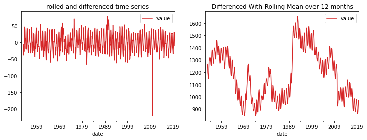

```python
#removing seasonality from the time series
rolling_mean_detrended_diff = rolling_mean_detrended - rolling_mean_detrended.shift()

ax1 = plt.subplot(121)
rolling_mean_detrended_diff.plot(figsize=(12,4),
                                 color="tab:red",
                                 title="rolled and differenced time series",
                                 ax=ax1)
ax1 = plt.subplot(122)
rolling_mean_detrended.plot(figsize=(12,4),color="tab:red",
                            title="Differenced With Rolling Mean over 12 months",
                            ax=ax1)
```

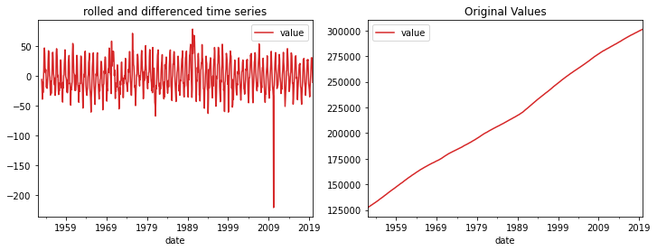

```python
ax1 = plt.subplot(121)
rolling_mean_detrended_diff.plot(figsize=(12,4),
                                 color="tab:red",
                                 title="rolled and differenced time series",
                                 ax=ax1)
ax2 = plt.subplot(122)
pop.plot(figsize=(12,4),
          color="tab:red",
          title="Original Values",
          ax=ax2)
```

```python
rolling_mean_detrended.shift().head(13)
```

| date | value |
| --- | --- |
| 1952-01-01 | NaN |
| 1952-02-01 | NaN |
| 1952-03-01 | NaN |
| 1952-04-01 | NaN |
| 1952-05-01 | NaN |
| 1952-06-01 | NaN |
| 1952-07-01 | NaN |
| 1952-08-01 | NaN |
| 1952-09-01 | NaN |
| 1952-10-01 | NaN |
| 1952-11-01 | NaN |
| 1952-12-01 | NaN |
| 1953-01-01 | 1264.416667 |

```python
rolling_mean_detrended_diff = rolling_mean_detrended_diff.dropna()
```

```python
rolling_mean_detrended_diff
```

| date | value |
| --- | --- |
| 1953-01-01 | -6.000000 |
| 1953-02-01 | -23.250000 |
| 1953-03-01 | -39.166667 |
| 1953-04-01 | -10.750000 |
| 1953-05-01 | -28.083333 |
| ... | ... |
| 2019-08-01 | 30.416417 |
| 2019-09-01 | 28.615333 |
| 2019-10-01 | 30.239250 |
| 2019-11-01 | 6.990250 |
| 2019-12-01 | -10.926750 |

804 rows × 1 columns

```python
result = adfuller(rolling_mean_detrended_diff['value'].dropna())
#print(result)

print('ADF Statistic: %f' % result[0])
print('p-value: %f' % result[1])
print('Critical Values:')
for key, value in result[4].items():
	print('\t%s: %.3f' % (key, value))
```

```
ADF Statistic: -5.189488
p-value: 0.000009
Critical Values:
	1%: -3.439
	5%: -2.865
	10%: -2.569
```

```python
dftest = adfuller(rolling_mean_detrended_diff['value'], autolag = 'AIC')  #AIC=Akaike information Cretaion
print("1. ADF : ",dftest[0])
print("2. P-Value : ", dftest[1])
print("3. Num Of Lags : ", dftest[2])
print("4. Num Of Observations Used For ADF Regression and Critical Values Calculation :", dftest[3])
print("5. Critical Values :")
for key, val in dftest[4].items():
  print("\t",key, ": ", val)
```

```
1. ADF :  -5.189488309413556
2. P-Value :  9.23709212731456e-06
3. Num Of Lags :  21
4. Num Of Observations Used For ADF Regression and Critical Values Calculation : 782
5. Critical Values :
	 1% :  -3.4387398917732193
	 5% :  -2.8652430432199654
	 10% :  -2.5687418568690683
```

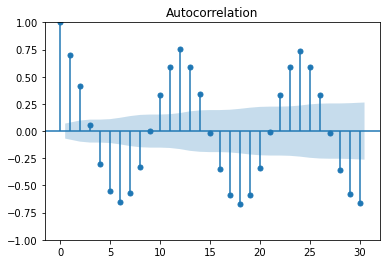

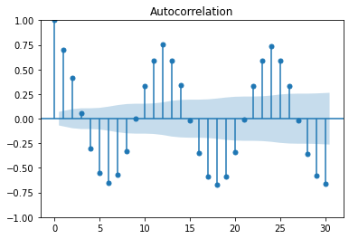

```python
from pandas.plotting import autocorrelation_plot
from statsmodels.graphics.tsaplots import plot_acf
#To check for the stationarity of the time series,
# statsmodels provides a plot_acf method to plot an autocorrelation plot.
plot_acf(rolling_mean_detrended_diff['value'])
```

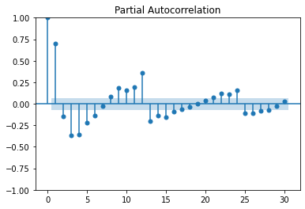

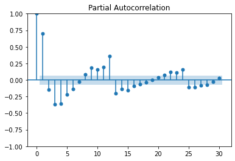

```python
from statsmodels.graphics.tsaplots import plot_pacf

plot_pacf(rolling_mean_detrended_diff['value'])
```

```python
!pip install pmdarima
from pmdarima import auto_arima
```

```python
order = auto_arima(rolling_mean_detrended_diff['value'], trace=True)
order.summary()
```

```
Performing stepwise search to minimize aic
 ARIMA(2,0,2)(0,0,0)[0] intercept   : AIC=6625.482, Time=1.56 sec
 ARIMA(0,0,0)(0,0,0)[0] intercept   : AIC=7594.994, Time=0.07 sec
 ARIMA(1,0,0)(0,0,0)[0] intercept   : AIC=7054.960, Time=0.14 sec
 ARIMA(0,0,1)(0,0,0)[0] intercept   : AIC=7227.236, Time=0.29 sec
 ARIMA(0,0,0)(0,0,0)[0]             : AIC=7593.150, Time=0.06 sec
 ARIMA(1,0,2)(0,0,0)[0] intercept   : AIC=7001.209, Time=0.58 sec
 ARIMA(2,0,1)(0,0,0)[0] intercept   : AIC=6898.669, Time=0.67 sec
 ARIMA(3,0,2)(0,0,0)[0] intercept   : AIC=6581.874, Time=2.46 sec
 ARIMA(3,0,1)(0,0,0)[0] intercept   : AIC=6809.062, Time=0.90 sec
 ARIMA(4,0,2)(0,0,0)[0] intercept   : AIC=6583.323, Time=2.05 sec
 ARIMA(3,0,3)(0,0,0)[0] intercept   : AIC=6623.872, Time=1.86 sec
 ARIMA(2,0,3)(0,0,0)[0] intercept   : AIC=6590.561, Time=1.55 sec
 ARIMA(4,0,1)(0,0,0)[0] intercept   : AIC=6781.017, Time=0.84 sec
 ARIMA(4,0,3)(0,0,0)[0] intercept   : AIC=6570.303, Time=2.38 sec
 ARIMA(5,0,3)(0,0,0)[0] intercept   : AIC=inf, Time=3.10 sec
 ARIMA(4,0,4)(0,0,0)[0] intercept   : AIC=6611.296, Time=3.51 sec
 ARIMA(3,0,4)(0,0,0)[0] intercept   : AIC=6584.031, Time=2.37 sec
 ARIMA(5,0,2)(0,0,0)[0] intercept   : AIC=6600.397, Time=2.49 sec
 ARIMA(5,0,4)(0,0,0)[0] intercept   : AIC=6564.933, Time=2.88 sec
 ARIMA(5,0,5)(0,0,0)[0] intercept   : AIC=6624.410, Time=3.28 sec
 ARIMA(4,0,5)(0,0,0)[0] intercept   : AIC=6565.890, Time=3.41 sec
 ARIMA(5,0,4)(0,0,0)[0]             : AIC=6567.585, Time=2.66 sec

Best model:  ARIMA(5,0,4)(0,0,0)[0] intercept
Total fit time: 39.496 seconds
```

SARIMAX Results

| Dep. Variable: | y | No. Observations: | 804 |
| --- | --- | --- | --- |
| Model: | SARIMAX(5, 0, 4) | Log Likelihood | -3271.466 |
| Date: | Mon, 12 Dec 2022 | AIC | 6564.933 |
| Time: | 21:41:05 | BIC | 6616.518 |
| Sample: | 01-01-1953 | HQIC | 6584.745 |
|  | - 12-01-2019 |  |  |
| Covariance Type: | opg |  |  |

|  | coef | std err | z | P>\|z\| | [0.025 | 0.975] |
| --- | --- | --- | --- | --- | --- | --- |
| intercept | -0.1054 | 0.604 | -0.175 | 0.861 | -1.288 | 1.078 |
| ar.L1 | 0.4219 | 0.055 | 7.702 | 0.000 | 0.315 | 0.529 |
| ar.L2 | 0.9440 | 0.052 | 18.048 | 0.000 | 0.841 | 1.046 |
| ar.L3 | -0.3929 | 0.066 | -5.944 | 0.000 | -0.523 | -0.263 |
| ar.L4 | -0.9407 | 0.046 | -20.386 | 0.000 | -1.031 | -0.850 |
| ar.L5 | 0.3566 | 0.026 | 13.751 | 0.000 | 0.306 | 0.407 |
| ma.L1 | -0.0565 | 0.051 | -1.104 | 0.270 | -0.157 | 0.044 |
| ma.L2 | -0.9005 | 0.057 | -15.820 | 0.000 | -1.012 | -0.789 |
| ma.L3 | 0.0232 | 0.058 | 0.399 | 0.690 | -0.091 | 0.137 |
| ma.L4 | 0.8998 | 0.050 | 17.886 | 0.000 | 0.801 | 0.998 |
| sigma2 | 198.7287 | 2.921 | 68.028 | 0.000 | 193.003 | 204.454 |

| Ljung-Box (L1) (Q): | 1.60 | Jarque-Bera (JB): | 99524.37 |
| --- | --- | --- | --- |
| Prob(Q): | 0.21 | Prob(JB): | 0.00 |
| Heteroskedasticity (H): | 1.63 | Skew: | -2.58 |
| Prob(H) (two-sided): | 0.00 | Kurtosis: | 57.26 |

Warnings:  
[1] Covariance matrix calculated using the outer product of gradients (complex-step).

```python
from statsmodels.tsa.arima_model import ARIMA
import statsmodels.api as sm
```

```python
train = rolling_mean_detrended_diff.iloc[:120]['value']
test = rolling_mean_detrended_diff.iloc[121:]['value']
# ARIMA ---> AR + MA +I ---> ARIMA--> 3= AR , I=0 , MA=3
model = sm.tsa.arima.ARIMA(train, order=(3,0,3))
model_fit = model.fit() # training
model_fit.summary()
```

SARIMAX Results

| Dep. Variable: | value | No. Observations: | 120 |
| --- | --- | --- | --- |
| Model: | ARIMA(3, 0, 3) | Log Likelihood | -474.415 |
| Date: | Mon, 12 Dec 2022 | AIC | 964.829 |
| Time: | 22:14:35 | BIC | 987.129 |
| Sample: | 01-01-1953 | HQIC | 973.886 |
|  | - 12-01-1962 |  |  |
| Covariance Type: | opg |  |  |

|  | coef | std err | z | P>\|z\| | [0.025 | 0.975] |
| --- | --- | --- | --- | --- | --- | --- |
| const | 0.3969 | 1.177 | 0.337 | 0.736 | -1.910 | 2.704 |
| ar.L1 | 0.7404 | 0.111 | 6.667 | 0.000 | 0.523 | 0.958 |
| ar.L2 | 0.7156 | 0.191 | 3.744 | 0.000 | 0.341 | 1.090 |
| ar.L3 | -0.9908 | 0.111 | -8.965 | 0.000 | -1.207 | -0.774 |
| ma.L1 | -0.7393 | 2.360 | -0.313 | 0.754 | -5.365 | 3.887 |
| ma.L2 | -0.6845 | 0.563 | -1.217 | 0.224 | -1.787 | 0.418 |
| ma.L3 | 0.9785 | 2.631 | 0.372 | 0.710 | -4.177 | 6.134 |
| sigma2 | 145.3730 | 389.339 | 0.373 | 0.709 | -617.717 | 908.463 |

| Ljung-Box (L1) (Q): | 12.17 | Jarque-Bera (JB): | 1.59 |
| --- | --- | --- | --- |
| Prob(Q): | 0.00 | Prob(JB): | 0.45 |
| Heteroskedasticity (H): | 1.40 | Skew: | 0.10 |
| Prob(H) (two-sided): | 0.29 | Kurtosis: | 2.47 |

Warnings:  
[1] Covariance matrix calculated using the outer product of gradients (complex-step).

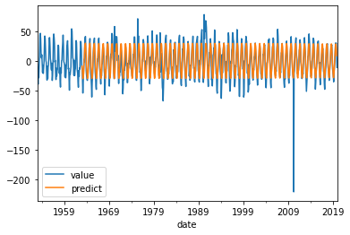

```python
rolling_mean_detrended_diff['predict'] = model_fit.predict(start= len(train),
                                    end=len(train)+len(test)- 1,
                                    dynamic=True)
rolling_mean_detrended_diff[['value','predict']].plot()
```

```python
from statsmodels.tsa.statespace.sarimax import SARIMAX, SARIMAXResults

model = SARIMAX(train, order=(1,0,2), seasonal_order=(1,0,2,12))
model = model.fit()
```

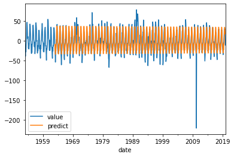

```python
rolling_mean_detrended_diff['predict'] = model.predict(start= len(train) ,
                                                       end=len(train)+len(test)- 1,
                                                       dynamic=True)
rolling_mean_detrended_diff[['value','predict']].plot()
```

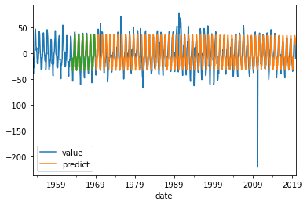

```python
#predicting the projections for the next 6 years

forecast = model.forecast(steps=72)
rolling_mean_detrended_diff.plot()
forecast.plot()
```

```python
type(forecast)
```

```
pandas.core.series.Series
```